# R Notebook - Perceptron

## Notebook com códigos R para a implementação do Perceptron - ERAMIA 2020

Carregando os dados - Exemplo com o dataset Iris

```r
data(iris)
```

Estatísticas sobre os dados

```r
dim(iris)
```

```
## [1] 150   5
```

```r
names(iris)
```

```
## [1] "Sepal.Length" "Sepal.Width"  "Petal.Length" "Petal.Width"  "Species"
```

```r
summary(iris$Species)
```

```
##     setosa versicolor  virginica
##         50         50         50
```

Vamos ver como os atributos separam os dados

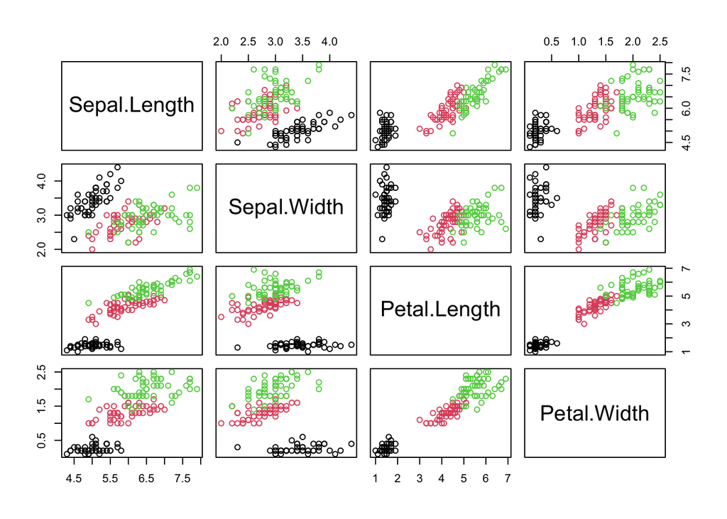

```r
pairs(iris[,1:4], col=iris$Species)
```

Vamos pegar os atributos Sepal Width e Petal Width, pois o Percetron só consegue separar dados linearmente separáveis

```r
x <- cbind(iris$Sepal.Width,iris$Petal.Width)
```

Agora vamos rotular Iris Setosa como positivo e o resto dos dados como negativo

```r
y <- ifelse(iris$Species == "setosa", +1, -1)
```

Vamos iniciar a implementação do Perceptron. Inicialmente vamos definir o bias e utilizá-lo como uma das entradas

```r
bias <- rep(1,nrow(x))
x <- cbind(x,bias)
```

Vamos agora concatenar as classes

```r
x <- cbind(x,y)
```

Vamos gerar os pesos iniciar aleatoriamente

```r
pesos <- runif(3,-1,1)
```

Código principal da função de treinamento do Perceptron. Essa função nos retornará os pesos atualizados do Perceptron. O treinamento será realizado até todos os exemplos de treino serem corretamente classificados.

```r
perceptron.treino <- function(dados,pesos){

    # Taxa de aprendizado
    n <- 0.3

    # Controle
    erro <- 1
    epocas <- 0

    while(erro == 1){
        erro <- 0
        epocas <- epocas + 1
        erroMedio <- 0
        for(i in 1:nrow(dados)){
            v <- 0
            # Potencial de ativacao
            for(j in 1:length(pesos)){
                v <- v + dados[i,j]*pesos[j]
            }

            # Funcao sinal
            y <- sign(v)
            erroMedio <- erroMedio + (dados[i,4] - y)*(dados[i,4] - y)

            # Atualizacao dos pesos
            if(dados[i,4] != y){
                erro <- 1
                for(j in 1:length(pesos)){
                    pesos[j] <- pesos[j] + n*(dados[i,4] - y)*dados[i,j]
                }
            }
        }
        erroMedio <- erroMedio/nrow(dados)
        cat("\nErro Medio = ",erroMedio)

    }
    cat("\nFinalizado com ",epocas," epocas\n")
    return(pesos)
}
```

Agora vamos chamar a função de treino do Perceptron, passsando como parâmetros os dados e os pesos.

```r
pesos.iris <- perceptron.treino(x,pesos)
```

```
##
## Erro Medio =  0.02666667
## Erro Medio =  0.05333333
## Erro Medio =  0.05333333
## Erro Medio =  0.05333333
## Erro Medio =  0.05333333
## Erro Medio =  0.05333333
## Erro Medio =  0.05333333
## Erro Medio =  0.05333333
## Erro Medio =  0.05333333
## Erro Medio =  0.05333333
## Erro Medio =  0.05333333
## Erro Medio =  0.05333333
## Erro Medio =  0.05333333
## Erro Medio =  0.05333333
## Erro Medio =  0
## Finalizado com  15  epocas
```

Vamos comparar os pesos iniciais com os pesos finais

```r
print(pesos)
```

```
## [1] 0.1388259 0.6727635 0.8446623
```

```r
print(pesos.iris)
```

```
## [1]  1.5188259 -8.3272365  0.2446623
```

Vamos ver como ficou o hiperplano aprendido pelo Perceptron. Inicialmente vamos plotar os dados de treinamento e depois traçar o hiperplano

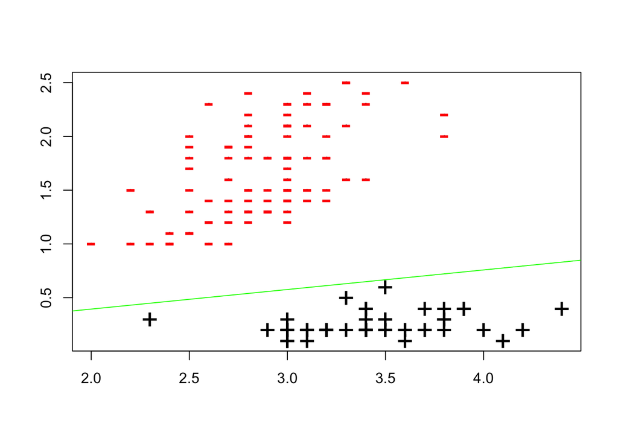

```r
# Plotando os dados
plot(x,cex=0.2)
points(subset(x,y==1),col="black",pch="+",cex=2)
points(subset(x,y==-1),col="red",pch="-",cex=2)

# Traçando o hiperplano
# Toda equação na forma y = mx + q é chamada equação reduzida da reta, em que m é o coeficiente angular, e q é a ordenada do ponto no qual a reta cruza o eixo y. A equação reduzida pode ser obtida diretamente da equação geral ax + by + c = 0. Assim:

# ax + by + c = 0 -> by = -ax –c

# y = -a/b x  - c/b

# m = -a/b
# q = -c/b
intercept <- - pesos.iris[3] / pesos.iris[2]
slope <- - pesos.iris[1] / pesos.iris[2]
abline(intercept,slope,col="green")
```

Precisamos agora de uma função para classificação de novos dados.

```r
perceptron <- function(exemplo,pesos){
    v <- 0
    for(i in 1:length(exemplo)){
        # Potencial de ativacao
        v <- v + exemplo[i]*pesos[i]
        # Funcao sinal
    }
    y <- sign(v)
    return(y)
}
```

Vamos agora criar alguns dados novos para testar nosso Perceptron

```r
novo.dado <- c(2.5,0.3,1)
perceptron(novo.dado,pesos.iris)
```

```
## [1] 1
```

```r
novo.dado <- c(2.5,1,1)
perceptron(novo.dado,pesos.iris)
```

```
## [1] -1
```